# Pivoting Wider on Delimited Column

## Introduction

First we load some tidyverse packages:

```r
library(dplyr)
library(tidyr)
library(stringr)
library(readr)
library(DT)
options(DT.options = list(searching = FALSE))
```

Example of a table with a delimited column:

```r
names_flavors_tbl <- readr::read_csv("./data/names_flavors_delim.csv", show_col_types = FALSE)

names_flavors_tbl |> DT::datatable()
```

|  | fname | lname | flavors |
| --- | --- | --- | --- |
| 1 | Emilio | Munson | chocolate, vanilla |
| 2 | Liz | Myers | vanilla |
| 3 | Rachelle | Hardy | lemon, vanilla, lime |
| 4 | Sam | Reeves | chocolate, lime |

### Case 1: Delimited Column Follows a Consistent Pattern

In a strict case, the delimited values may follow a very consistent format. For example:

`crew-XXL-blue`  
`crew-M-blue`  
`vneck-L-white`

If we had a column like this, we could use `tidyr::separate_wider_delim()`, and split the delimited column into additional columns by specify the delimiter character or position. Unfortunately, the ‘flavors’ column above doesn’t follow a consistent pattern, because some people have one favorite flavor, and others multiple.

### Case 2 (our case): Variable length and order

In the most generic case, the delimited values may be of varying length. This can be seen in the sample data above, where some rows have a single value in ‘flavors’, and others have multiple. They are also not in any particular order.

### Desired Output

Our desired output has the delimited values as individual columns, shown as follows:

```r
readr::read_csv("./data/names_flavors_wide.csv", show_col_types = FALSE) |> datatable()
```

|  | fname | lname | chocolate | vanilla | lemon | lime |
| --- | --- | --- | --- | --- | --- | --- |
| 1 | Emilio | Munson | True | True | False | False |
| 2 | Liz | Myers | False | True | False | False |
| 3 | Rachelle | Hardy | False | True | True | True |
| 4 | Sam | Reeves | True | False | False | True |

## Best Option: Go Long, Then Wide

There are a few ways to do this, but the one that is the cleanest involves using dplyr and tidyr to i) split the delimited column into rows (i.e., go long), ii) add a column for the values that will go into the new columns, and iii) use that new column to pivot from longer to wider.

### Step 1: Go Long

The first step is to convert the individual values in the delimited column to extra rows, using tidyr::separate_longer_delim. To deal whitespace before or after the delimiters, we follow that up with str_trim:

```r
names_flavors_long_tbl <- names_flavors_tbl |>
  separate_longer_delim(flavors, delim = ",") |>    ## split individual values in 'flavors' column into rows
  mutate(flavor = str_trim(flavors)) |>             ## trim leading/trailing white space
  select(!flavors)                                  ## drop the 'flavors' column

names_flavors_long_tbl |> datatable()
```

|  | fname | lname | flavor |
| --- | --- | --- | --- |
| 1 | Emilio | Munson | chocolate |
| 2 | Emilio | Munson | vanilla |
| 3 | Liz | Myers | vanilla |
| 4 | Rachelle | Hardy | lemon |
| 5 | Rachelle | Hardy | vanilla |
| 6 | Rachelle | Hardy | lime |
| 7 | Sam | Reeves | chocolate |
| 8 | Sam | Reeves | lime |

### Step 2: Add a Values Column and Pivot

We now have a well-structured long table. Before we pivot wider, we have to add a column containing the values that will go in the new columns. In this example, we use a ‘presence/absence’ logic:

```r
names_flavors_wide_tbl <- names_flavors_long_tbl |>
  mutate(fav = TRUE) |>
  pivot_wider(id_cols = c(fname, lname), names_from = flavor, values_from = fav)

names_flavors_wide_tbl |> datatable()
```

|  | fname | lname | chocolate | vanilla | lemon | lime |
| --- | --- | --- | --- | --- | --- | --- |
| 1 | Emilio | Munson | True | True |  |  |
| 2 | Liz | Myers |  | True |  |  |
| 3 | Rachelle | Hardy |  | True | True | True |
| 4 | Sam | Reeves | True |  |  | True |

### Step 3: Deal with `NAs`

To convert the `NA` cells to `FALSE` we can use `mutate()` with an `across()` expression that in turn calls `replace_na()`:

```r
names_flavors_wide_tf_tbl <- names_flavors_wide_tbl |>
  mutate(across(-c(fname, lname), ~replace_na(., FALSE)))

names_flavors_wide_tf_tbl |> datatable()
```

|  | fname | lname | chocolate | vanilla | lemon | lime |
| --- | --- | --- | --- | --- | --- | --- |
| 1 | Emilio | Munson | True | True | False | False |
| 2 | Liz | Myers | False | True | False | False |
| 3 | Rachelle | Hardy | False | True | True | True |
| 4 | Sam | Reeves | True | False | False | True |

### Final Answer

Putting it all together as a single piped expression, we get:

```r
names_flavors_yn_tbl <- names_flavors_tbl |>
  separate_longer_delim(flavors, delim = ",") |>    ## split individual values in 'flavors' column into rows
  mutate(flavor = str_trim(flavors)) |>             ## trim leading/trailing white space
  select(!flavors) |>                               ## drop the 'flavors' column
  mutate(fav = TRUE) |>                             ## add a column for the values that will go in the cols
  pivot_wider(id_cols = c(fname, lname),            ## pivot wider
              names_from = flavor,
              values_from = fav) |>
  mutate(across(-c(fname, lname),                   ## replace NAs with FALSE
                ~replace_na(., FALSE)))

names_flavors_yn_tbl |> datatable()
```

|  | fname | lname | chocolate | vanilla | lemon | lime |
| --- | --- | --- | --- | --- | --- | --- |
| 1 | Emilio | Munson | True | True | False | False |
| 2 | Liz | Myers | False | True | False | False |
| 3 | Rachelle | Hardy | False | True | True | True |
| 4 | Sam | Reeves | True | False | False | True |

## Fill New Columns with Normalized Values

This example is similar to the one above, but here we fill the columns not with Logical values, but with numeric values normalized by the number of values in the delimited column. This would be appropriate for example if there was an assumption that numeric value (number of dollars, amount of time, etc.) was distributed evenly across the entities in the ‘many’ column.

Our (fake) sample dataset contains the grant amounts received by different non-profits to implement programs in one or more counties:

```r
grantees_counties_tbl <- read_csv("./data/grantees_counties.csv")

grantees_counties_tbl |> datatable()
```

|  | grantee_name | grantee_award | counties |
| --- | --- | --- | --- |
| 1 | Central Valley Health | 10000 | Tulare, Kings, Fresno |
| 2 | Tri Valley Food Coop | 50000 | Sacramento, San Joaquin, Sutter, Yolo |
| 3 | Healthy Kids SoCal | 5000 | San Diego, Imperial |
| 4 | Bay Area EatMore | 38000 | Contra Costa, Alameda, Santa Clara, San Mateo, San Francisco |
| 5 | Tahoe Nutrition | 12000 | El Dorado, Placer |
| 6 | Contra Costa Farmers Alliance | 8000 | Contra Costa |

As above, step 1 is to convert the delimited ‘counties’ column into extra rows with a single ‘county’ column:

```r
grantees_counties_long_tbl <- grantees_counties_tbl |>
  separate_longer_delim(counties, delim = ",") |>
  mutate(county = str_trim(counties)) |>
  select(!counties)

grantees_counties_long_tbl |> datatable()
```

|  | grantee_name | grantee_award | county |
| --- | --- | --- | --- |
| 1 | Central Valley Health | 10000 | Tulare |
| 2 | Central Valley Health | 10000 | Kings |
| 3 | Central Valley Health | 10000 | Fresno |
| 4 | Tri Valley Food Coop | 50000 | Sacramento |
| 5 | Tri Valley Food Coop | 50000 | San Joaquin |
| 6 | Tri Valley Food Coop | 50000 | Sutter |
| 7 | Tri Valley Food Coop | 50000 | Yolo |
| 8 | Healthy Kids SoCal | 5000 | San Diego |
| 9 | Healthy Kids SoCal | 5000 | Imperial |
| 10 | Bay Area EatMore | 38000 | Contra Costa |

[output cut: 7 more lines]

Next we add a column containing the award amount per county (assuming even distribution). We can do this by combining `group_by()` with `mutate()`. When `mutate()` comes after `group_by()`, any aggregate functions in the mutate expression (like `mean()` or `n()`) are applied to the group of rows, and you get back all of the rows.

```r
awards_by_county_tbl <- grantees_counties_long_tbl |>
  group_by(grantee_name) |>
  mutate(county_amt = grantee_award / n())

awards_by_county_tbl |> datatable()
```

|  | grantee_name | grantee_award | county | county_amt |
| --- | --- | --- | --- | --- |
| 1 | Central Valley Health | 10000 | Tulare | 3333.333333333333 |
| 2 | Central Valley Health | 10000 | Kings | 3333.333333333333 |
| 3 | Central Valley Health | 10000 | Fresno | 3333.333333333333 |
| 4 | Tri Valley Food Coop | 50000 | Sacramento | 12500 |
| 5 | Tri Valley Food Coop | 50000 | San Joaquin | 12500 |
| 6 | Tri Valley Food Coop | 50000 | Sutter | 12500 |
| 7 | Tri Valley Food Coop | 50000 | Yolo | 12500 |
| 8 | Healthy Kids SoCal | 5000 | San Diego | 2500 |
| 9 | Healthy Kids SoCal | 5000 | Imperial | 2500 |
| 10 | Bay Area EatMore | 38000 | Contra Costa | 7600 |

[output cut: 7 more lines]

If we wanted to see the amount by each grantee, we could pivot wider on the `grantee_name` column:

```r
awards_by_county_tbl |>
  pivot_wider(id_cols = !grantee_award,
              names_from = grantee_name,
              values_from = county_amt) |>
  datatable()
```

|  | county | Central Valley Health | Tri Valley Food Coop | Healthy Kids SoCal | Bay Area EatMore | Tahoe Nutrition | Contra Costa Farmers Alliance |
| --- | --- | --- | --- | --- | --- | --- | --- |
| 1 | Tulare | 3333.333333333333 |  |  |  |  |  |
| 2 | Kings | 3333.333333333333 |  |  |  |  |  |
| 3 | Fresno | 3333.333333333333 |  |  |  |  |  |
| 4 | Sacramento |  | 12500 |  |  |  |  |
| 5 | San Joaquin |  | 12500 |  |  |  |  |
| 6 | Sutter |  | 12500 |  |  |  |  |
| 7 | Yolo |  | 12500 |  |  |  |  |
| 8 | San Diego |  |  | 2500 |  |  |  |
| 9 | Imperial |  |  | 2500 |  |  |  |
| 10 | Contra Costa |  |  |  | 7600 |  | 8000 |

[output cut: 6 more lines]

We may also want to compute the totals by county:

```r
awards_county_totals_tbl <- awards_by_county_tbl |>
  group_by(county) |>
  summarise(county_total = round(sum(county_amt)), .groups = "drop_last")

awards_county_totals_tbl |> datatable()
```

|  | county | county_total |
| --- | --- | --- |
| 1 | Alameda | 7600 |
| 2 | Contra Costa | 15600 |
| 3 | El Dorado | 6000 |
| 4 | Fresno | 3333 |
| 5 | Imperial | 2500 |
| 6 | Kings | 3333 |
| 7 | Placer | 6000 |
| 8 | Sacramento | 12500 |
| 9 | San Diego | 2500 |
| 10 | San Francisco | 7600 |

[output cut: 6 more lines]

### Create a Map

We can create a choropleth map by joining the county totals to the counties spatial layer:

Import the counties:

```r
library(sf)
ca_counties_sf <- st_read("./data/ca_counties.geojson")
head(ca_counties_sf)
```

```
Simple feature collection with 6 features and 2 fields
Geometry type: MULTIPOLYGON
Dimension:     XY
Bounding box:  xmin: -124.4096 ymin: 32.80146 xmax: -117.6464 ymax: 41.46584
Geodetic CRS:  WGS 84
  GEOID          COUNTY                       geometry
1 06037     Los Angeles MULTIPOLYGON (((-118.6044 3...
2 06023        Humboldt MULTIPOLYGON (((-124.4086 4...
3 06097          Sonoma MULTIPOLYGON (((-123.5331 3...
4 06079 San Luis Obispo MULTIPOLYGON (((-121.3464 3...
5 06089          Shasta MULTIPOLYGON (((-123.0688 4...
6 06039          Madera MULTIPOLYGON (((-120.5455 3...
```

Do a left join (to keep all the counties, even if there are no awards to them):

```r
ca_counties_amts_sf <- ca_counties_sf |>
  left_join(awards_county_totals_tbl, by = c("COUNTY" = "county"))

ca_counties_amts_sf |>
  arrange(desc(county_total)) |>
  datatable()
```

|  | GEOID | COUNTY | county_total | geometry |
| --- | --- | --- | --- | --- |
| 1 | 06013 | Contra Costa | 15600 | {'type': 'MultiPolygon', 'coordinates': [[[[-122.42976, 37.965405], [-122.418592, 37.964784], [-122.41265, 37.963285], [-122.411761, 37.960497], [-122.408383, 37.957544], [-122.402906, 37.954852], [-1… |
| 2 | 06113 | Yolo | 12500 | {'type': 'MultiPolygon', 'coordinates': [[[[-122.421488, 38.90233], [-122.421904, 38.90377], [-122.41904, 38.905946], [-122.417264, 38.906378], [-122.41584, 38.907674], [-122.416512, 38.909562], [-122… |
| 3 | 06101 | Sutter | 12500 | {'type': 'MultiPolygon', 'coordinates': [[[[-121.948283, 39.241767], [-121.947368, 39.243572], [-121.94666, 39.247685], [-121.946821, 39.249842], [-121.945278, 39.253101], [-121.94226, 39.256097], [-1… |
| 4 | 06067 | Sacramento | 12500 | {'type': 'MultiPolygon', 'coordinates': [[[[-121.862542, 38.06795], [-121.861597, 38.069887], [-121.857613, 38.071967], [-121.852909, 38.072847], [-121.848541, 38.074223], [-121.843228, 38.076655], [-… |
| 5 | 06077 | San Joaquin | 12500 | {'type': 'MultiPolygon', 'coordinates': [[[[-121.584719, 38.043545], [-121.582305, 38.051436], [-121.582427, 38.053807], [-121.583511, 38.05928], [-121.583879, 38.059897], [-121.582244, 38.064388], [-… |
| 6 | 06081 | San Mateo | 7600 | {'type': 'MultiPolygon', 'coordinates': [[[[-122.520852, 37.594178], [-122.515326, 37.595564], [-122.514724, 37.598285], [-122.514290175257, 37.5981491998578], [-122.507648, 37.59607], [-122.507464202… |
| 7 | 06085 | Santa Clara | 7600 | {'type': 'MultiPolygon', 'coordinates': [[[[-122.202653, 37.363046], [-122.201318, 37.367013], [-122.2016, 37.368008], [-122.201007, 37.371215], [-122.200706, 37.371964], [-122.199328, 37.372671], [-1… |
| 8 | 06001 | Alameda | 7600 | {'type': 'MultiPolygon', 'coordinates': [[[[-122.342253, 37.805558], [-122.334118407598, 37.8103448459501], [-122.332638, 37.811216], [-122.3286071261, 37.8108026210171], [-122.323238, 37.810252], [-1… |
| 9 | 06075 | San Francisco | 7600 | {'type': 'MultiPolygon', 'coordinates': [[[[-122.332250181184, 37.7820688515023], [-122.332211831023, 37.7831367051245], [-122.332045780727, 37.7877603470098], [-122.331536, 37.786942], [-122.32800518… |
| 10 | 06061 | Placer | 6000 | {'type': 'MultiPolygon', 'coordinates': [[[[-121.48444, 38.751354], [-121.469753, 38.751603], [-121.469778, 38.766103], [-121.469628, 38.795199], [-121.469809, 38.824279], [-121.469675, 38.844103], [-… |

[output cut: 48 more lines]

Create a choropleth map:

```r
library(tmap)
tmap_mode("plot")
```

```
tmap mode set to plotting
```

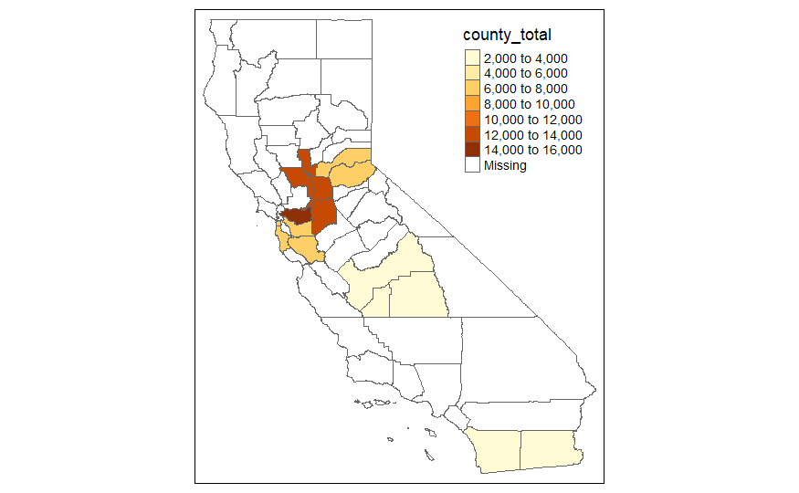

```r
tm_shape(ca_counties_amts_sf) +
  tm_polygons(col = "county_total", n = 5, colorNA = "#ffffff")
```

```r
# Interactive tmap maps don't work well in notebooks
tmap_mode("view")
```

```
tmap mode set to interactive viewing
```